# R Notebook

#load data Photoperiod data: - species - photoperiodism: photoperiod sensitivity requirements(ad, id, ld, sd, ldsd, lsd, sd, sld, yes (exists in unknown form), na) - cultivar: if present, cultivar name - reference: source of information - notes: additional notes on photoperiod sensitivity - sensitivity_yn: binary variable of whether photoperiod sensitivity in any form exists in species

Flowering time data: - species - year: year of record - doy: day of year - source: source of information

```r
library(tidyverse)
library(ggplot2) #for graphs

pp <- read.csv("./Data/appendix1.csv") #read in photoperiod data
pp$species <- gsub("_", " ",pp$species)
ft <- read.csv("./data/appendix2.csv") #read completed flowering time data

df <- left_join(ft, pp, by = "species")
rm(pp)
rm(ft)
```

#remove data without long, short or no daylenth requirement. This is mostly because they have multiple requirements in a specific order.

```r
df$simple_photoperiodism <- as.factor(df$simple_photoperiodism) #make it a factor
df$simple_photoperiodism <- relevel(df$simple_photoperiodism, "na") #relevel so na is the reference factor

df_final <- df %>%
  filter(simple_photoperiodism != "other") #filter
```

#a quick summary of our data

```r
summary(df_final)
```

[output not shown]

#map data

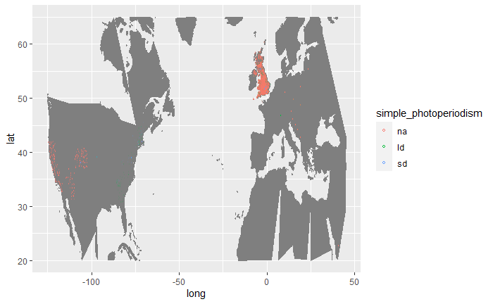

```r
map_base <- ggplot() + #specify map base
  borders("world", colour="gray50", fill="gray50")

map_pp <- map_base + #use map base
  geom_jitter(data = df, aes(x = lon, y = lat, colour = simple_photoperiodism), size = 0.05, alpha = 0.1, shape = 1) +#layer points on map
  xlim(-125, 45)+ #set x limits based on summary
  ylim(20, 65)+#set y limits based on summary
  guides(colour = guide_legend(override.aes = list(size = 1, alpha = 1))) #override the transparency and size to make legend readable

map_pp
```

#Analyse data

```r
library(tidyverse)
library(lme4)
library(lmerTest)
#lm_basic <- lmer(doy ~ sensitivity_yn*year + (1|species), data = df) #original model with species and binary sensitivity

#lm_groups <- lmer(doy ~ simple_photoperiodism*year + (1|species), data = df) #improved model with species and groups of sensitivity

#lm_latitude <- lmer(doy ~ sensitivity_yn*year + (1|species) + lat, data = df) #improved model as above with latitude as fixed effect

lm_final <- lmer(doy ~ simple_photoperiodism*year + (1|species) + lat, data = df_final)#improved model with all aspects of previous models with 'other' group removed

lm_comparison <- lmer(doy ~ year + (1|species) + lat, data = df_final) #comparison model to lm_final with photoperiodism removed as variable
```

#check assumptions of model

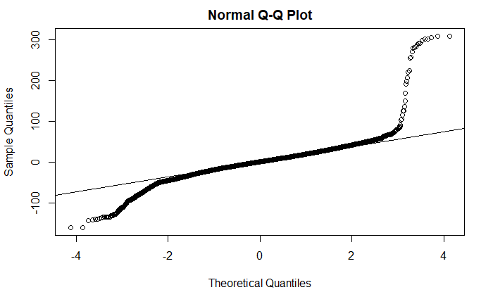

```r
qqnorm(resid(lm_final)) #qqplot
qqline(resid(lm_final)) #add line
```

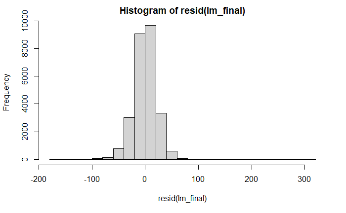

```r
hist(resid(lm_final), breaks = 25) #look at normality of residuals
```

The qq plot seems heavy tailed at the start but after looking at the histogram, the proportion of samples in the tail is very small compared to the main section, which fits pretty well.

#Comparing our final model with the others To determine whether photoperiod information improves our flowering time model, let’s see compare the pair

```r
anova(lm_final, lm_comparison) #compare the pair statistically
```

```
refitting model(s) with ML (instead of REML)
```

```
Data: df_final
Models:
lm_comparison: doy ~ year + (1 | species) + lat
lm_final: doy ~ simple_photoperiodism * year + (1 | species) + lat
              npar    AIC    BIC  logLik deviance  Chisq Df Pr(>Chisq)
lm_comparison    5 244982 245023 -122486   244972
lm_final         9 244786 244860 -122384   244768 204.26  4  < 2.2e-16 ***
---
Signif. codes:  0 ‘***’ 0.001 ‘**’ 0.01 ‘*’ 0.05 ‘.’ 0.1 ‘ ’ 1
```

The AICs on their own suggest that photoperiod does improve the model, and the ANOVA shows that this improvement is significant!

#Comparing our final models through bootstrapping

```r
library(pbkrtest)

bootstrap <- PBmodcomp(lm_final, lm_comparison, nsim = 599) #bootstrap comparison
bootstrap
```

[output not shown]

#Look at what our model tells us

```r
summary(lm_final) #look at our model
```

```
Linear mixed model fit by REML. t-tests use Satterthwaite's method ['lmerModLmerTest']
Formula: doy ~ simple_photoperiodism * year + (1 | species) + lat
   Data: df_final

REML criterion at convergence: 244771.8

Scaled residuals:
    Min      1Q  Median      3Q     Max
-7.0181 -0.5300  0.0226  0.5637 13.5220

Random effects:
 Groups   Name        Variance Std.Dev.
 species  (Intercept) 1632.6   40.41
 Residual              524.5   22.90
Number of obs: 26856, groups:  species, 81

Fixed effects:
                               Estimate Std. Error         df t value Pr(>|t|)
(Intercept)                   5.252e+02  3.105e+01  9.657e+03  16.917  < 2e-16 ***
simple_photoperiodismld      -3.817e+02  5.404e+01  1.682e+04  -7.064 1.68e-12 ***
simple_photoperiodismsd      -1.222e+03  9.953e+01  2.409e+04 -12.277  < 2e-16 ***
year                         -2.373e-01  1.568e-02  2.683e+04 -15.132  < 2e-16 ***
lat                           1.558e+00  4.123e-02  2.685e+04  37.794  < 2e-16 ***
simple_photoperiodismld:year  2.028e-01  2.666e-02  2.682e+04   7.608 2.87e-14 ***
simple_photoperiodismsd:year  6.374e-01  4.959e-02  2.680e+04  12.854  < 2e-16 ***
---
Signif. codes:  0 ‘***’ 0.001 ‘**’ 0.01 ‘*’ 0.05 ‘.’ 0.1 ‘ ’ 1

Correlation of Fixed Effects:
                (Intr) smpl_phtprdsml smpl_phtprdsms year   lat    smpl_phtprdsml:
smpl_phtprdsml  -0.581
smpl_phtprdsms  -0.366  0.214
year            -0.963  0.561          0.362
lat              0.525 -0.314         -0.267         -0.590
smpl_phtprdsml:  0.553 -0.979         -0.206         -0.573  0.321
smpl_phtprdsms:  0.350 -0.204         -0.993         -0.367  0.273  0.209
```

Less important observations: - plants in general are advancing at 2.4 days per decade - plants in general flower 1.5 days later for every degree they are away from the equator

#look at each photoperiod group seperately in case it helps

```r
lm_na <- lmer(doy ~ year + (1|species) + lat, data = df_final, subset = simple_photoperiodism == "na")

lm_sd <- lmer(doy ~ year + (1|species) + lat, data = df_final, subset = simple_photoperiodism == "sd")

lm_ld <- lmer(doy ~ year + (1|species) + lat, data = df_final, subset = simple_photoperiodism == "ld")

summary(lm_na)
```

```
Linear mixed model fit by REML. t-tests use Satterthwaite's method ['lmerModLmerTest']
Formula: doy ~ year + (1 | species) + lat
   Data: df_final
 Subset: simple_photoperiodism == "na"

REML criterion at convergence: 147146.1

Scaled residuals:
    Min      1Q  Median      3Q     Max
-6.2242 -0.5877  0.0015  0.5669 13.7244

Random effects:
 Groups   Name        Variance Std.Dev.
 species  (Intercept) 1176.9   34.31
 Residual              509.2   22.56
Number of obs: 16208, groups:  species, 25

Fixed effects:
              Estimate Std. Error         df t value Pr(>|t|)
(Intercept)  5.970e+02  3.160e+01  6.041e+03   18.89   <2e-16 ***
year        -2.782e-01  1.626e-02  1.620e+04  -17.11   <2e-16 ***
lat          1.740e+00  4.646e-02  1.620e+04   37.45   <2e-16 ***
---
Signif. codes:  0 ‘***’ 0.001 ‘**’ 0.01 ‘*’ 0.05 ‘.’ 0.1 ‘ ’ 1

Correlation of Fixed Effects:
     (Intr) year
year -0.974
lat   0.581 -0.642
```

```r
summary(lm_sd)
```

```
Linear mixed model fit by REML. t-tests use Satterthwaite's method ['lmerModLmerTest']
Formula: doy ~ year + (1 | species) + lat
   Data: df_final
 Subset: simple_photoperiodism == "sd"

REML criterion at convergence: 11785.3

Scaled residuals:
    Min      1Q  Median      3Q     Max
-5.3937 -0.4796  0.0757  0.4755 12.6725

Random effects:
 Groups   Name        Variance Std.Dev.
 species  (Intercept) 2052.5   45.30
 Residual              350.3   18.72
Number of obs: 1345, groups:  species, 24

Fixed effects:
              Estimate Std. Error         df t value Pr(>|t|)
(Intercept)  623.58588   85.57230 1341.73910   7.287 5.38e-13 ***
year          -0.14598    0.04109 1325.03100  -3.553 0.000394 ***
lat           -3.71217    0.16013 1334.16334 -23.182  < 2e-16 ***
---
Signif. codes:  0 ‘***’ 0.001 ‘**’ 0.01 ‘*’ 0.05 ‘.’ 0.1 ‘ ’ 1

Correlation of Fixed Effects:
     (Intr) year
year -0.991
lat  -0.465  0.401
```

```r
summary(lm_ld)
```

```
Linear mixed model fit by REML. t-tests use Satterthwaite's method ['lmerModLmerTest']
Formula: doy ~ year + (1 | species) + lat
   Data: df_final
 Subset: simple_photoperiodism == "ld"

REML criterion at convergence: 84972.5

Scaled residuals:
    Min      1Q  Median      3Q     Max
-6.9683 -0.4788  0.0391  0.5730 12.1513

Random effects:
 Groups   Name        Variance Std.Dev.
 species  (Intercept) 1693.1   41.15
 Residual              532.8   23.08
Number of obs: 9303, groups:  species, 32

Fixed effects:
              Estimate Std. Error         df t value Pr(>|t|)
(Intercept)  135.42207   44.35707 7655.04368   3.053  0.00227 **
year          -0.04283    0.02207 9290.39858  -1.941  0.05233 .
lat            2.05341    0.09498 9293.42794  21.620  < 2e-16 ***
---
Signif. codes:  0 ‘***’ 0.001 ‘**’ 0.01 ‘*’ 0.05 ‘.’ 0.1 ‘ ’ 1

Correlation of Fixed Effects:
     (Intr) year
year -0.980
lat  -0.035 -0.072
```

#plot graph

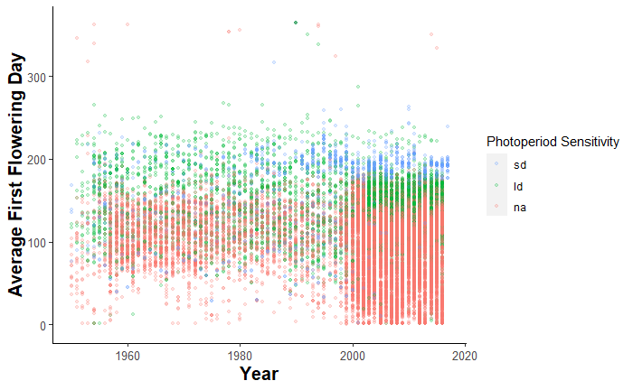

```r
ggplot.photogroups <-
  ggplot(subset(df_final))+
  geom_point(aes(y = doy, x = year, colour = simple_photoperiodism), size = 1, alpha = 0.2)+
  xlab("Year")+
  ylim(-4, 366)+
  xlim(1950, 2017)+
  ylab("Average First Flowering Day")+
  guides(color = guide_legend(title = "Photoperiod Sensitivity", reverse = TRUE))+
  theme(panel.grid.major = element_blank(),
        panel.grid.minor = element_blank(),
        panel.background = element_blank(),
        axis.line = element_line(colour = "black"),
        axis.text = element_text(size = 10),
        axis.title = element_text(size = 15, face  = "bold"))

ggplot.photogroups
```